# Introduction to Sargent

Nima Nouri and Katherine Norwood

28 September 2022

#### Package

sargent 1.0.0

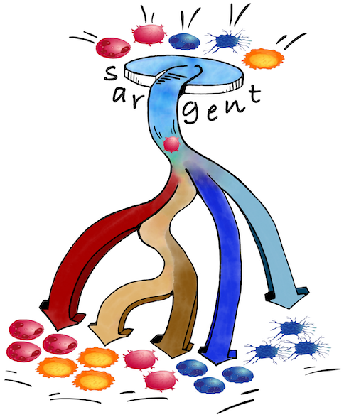

Sargent logo.

Thank you for your interest in Sargent! Sargent is a normalization-free, cluster-free, and single cell-based annotation algorithm for rapidly identifying the cell-types of origin based on sets of cell type-specific marker genes. This vignette gives an overview and introduction to Sargent’s functionality.

# 1 Installation

Sargent can be installed from Bioconductor:

```r
if (!require("BiocManager", quietly=TRUE))
    install.packages("BiocManager")
BiocManager::install("sargent")
```

# 2 Setup

To run the examples in this tutorial, you will need to install the `Seurat`, `ggplot2`, and `dplyr` packages. Once all installed, they can be loaded with the following commands:

```r
# Load required packages
library(Seurat)
library(ggplot2)
library(dplyr)
library(sargent)
```

A small example database, `sargentDemoData`, is included in the `sargent` package. This database contains a small subset of 100 cells from human kidney from Tabula Sapiens Consortium (Consortium* et al. 2022), manually annotated by experts. This database contains multiple items, but for the sake of this tutorial we will only need the gene expression matrix (`gex`) and associated meta-data (`mt.data`). The expression matrix is from a single-cell RNA-seq dataset and is formatted with genes as rows and cells as columns. We extract the relevant information for this demo using the following commands:

```r
# Access gene expression
gex <- get(data("sargentDemoData"))$gex
print(dim(gex))
```

```
## [1] 18992   100
```

```r
print(gex[1:10,1:10])
## 10 x 10 sparse Matrix of class "dgCMatrix"
##
## AP006222.1  .  .  .  .  .  .  .  .  .  .
## AL669831.3  .  .  .  .  .  .  .  .  .  .
## MTND1P23   64 11 28 29 52 24 29 17 20 23
## MTND2P28    3  .  2  .  2  1  .  .  .  .
## MTCO1P12   11  .  5  6  3  5  9  3  4  2
## MTCO2P12    .  .  .  1  .  .  .  .  .  .
## MTATP8P1    .  .  .  .  .  .  .  .  .  .
## MTATP6P1   52 13 45 43 59 41 29 22 38 27
## MTCO3P12    .  .  .  .  .  .  1  .  .  .
## AL669831.1  .  .  .  .  .  .  .  .  .  .

# Access meta data
mt.data <- get(data("sargentDemoData"))$mt.data
print(dim(mt.data))
```

```
## [1] 100   3
```

```r
print(head(mt.data))
```

```
##                                         organ_tissue  free_annotation celltype
## AACAAGACACCGGTCA_TSP2_Kidney_NA_10X_1_1       Kidney endothelial cell     Endo
## ACTTAGGCAATTGTGC_TSP2_Kidney_NA_10X_1_1       Kidney           b cell        B
## AGAAGTAGTTAGCGGA_TSP2_Kidney_NA_10X_1_1       Kidney           b cell        B
## AGACCCGGTGGTTTGT_TSP2_Kidney_NA_10X_1_1       Kidney       macrophage      MPh
## AGATAGAAGGAACGAA_TSP2_Kidney_NA_10X_1_1       Kidney       macrophage      MPh
## AGTACTGTCGCTGATA_TSP2_Kidney_NA_10X_1_1       Kidney           b cell        B
```

There are three columns in `mt.data`: 1) `organ_tissue` contains organ tissue information, 2) `free_annotation` contains experts’ annotation, and 3) `celltype` contains abbreviations for cell-type compartments, e.g. `B` for B cells, `MPh` for Myeloid-lineage cells, `TNK` for T and Natural killer cells, `Endo` for Endothelial, and `Epit` for Epithelial:

```r
print(table(mt.data$free_annotation, mt.data$celltype))
```

```
##
##                                    B Endo Epit MPh TNK
##   b cell                          19    0    0   0   0
##   cd4-positive helper t cell       0    0    0   0   5
##   cd8-positive, alpha-beta t cell  0    0    0   0   7
##   endothelial cell                 0   16    0   0   0
##   kidney epithelial cell           0    0   24   0   0
##   macrophage                       0    0    0  24   0
##   nk cell                          0    0    0   0   5
```

The `TNK` is a curated group, for the sake of this tutorial, to combine cell-types of similar phenotypes (e.g., T and Natural killer cells). In Section 4 of this tutorial, we will demonstrate how to split this group back into their original sub-types.

The other input required for annotation is annotating recipe: a list of gene-sets to explore on the cells. This is the fundamental building block of `sargent` and an important information for an accurate outcome. Therefore, investigators should have a broad understanding of cells and corresponding markers they expect to observe in the tissue under investigation. In this demo, for instance, we are exploring cells from Kidney, so one would expect to discover Immune, Endothelial, and Epithelial cell-types. Cell-type signatures should be provided in a vector format stored in a list:

```r
gene.sets <- list("Endo" = c("TGFBR2", "NOTCH4", "ADGRL4", "EMCN", "ENG",
                             "PECAM1", "PLVAP", "TEK", "KDR", "EPCAM",
                             "GJA5", "CDH5", "SEMA3G", "PTPRB", "SLC14A1"),
                  "Epit" = c("ANPEP", "AQP1", "SLC13A3", "SLC16A9", "SLC17A3",
                             "SLC22A7", "SLC22A8"),
                  "TNK" = c("CD4", "CD3D", "CD3E", "CD3G", "IL7R", "CD8A",
                            "CD8B", "FOXP3", "TIGIT", "CD27", "NCAM1", "KLRF1",
                            "GNLY", "NKG7", "TNFRSF18"),
                  "B" = c("CD79A", "CD79B", "MS4A1", "CD19", "JCHAIN"),
                  "MPh" = c("CD4", "MS4A7", "VCAN", "CD14", "FCN1", "LYZ",
                            "FCGR3A", "ITGAM", "MARCO", "CD1C", "ITGAX"))
```

Annotation in `sargent` is performed in three sequential steps:

**Scoring**: `sargent` uses a score-based procedure to infer the cell-type of origin for each cell among given gene-sets. This procedure transforms an input gene-by-cell expression matrix into a corresponding gene-set-by-cell assignment score matrix. Then, each individual cell is labeled with the cell-type with the highest assignment score.

**Trimming**: `sargent` uses a measure of dispersion, gini-index, to identify ambiguous calls. First, it calculates a gini-index among assignment scores per cell, transforming the gene-set-by-cell assignment score matrix to a distribution of indexes. Then, two conditions are evaluated. First, whether the gini-index is more than `gini.sigma` (adjustable) below the mean of distribution. The default `gini.sigma` is equal to 3 and is motivated by the fact that for a normal distribution, 99.7% of observations lie within three standard deviations of the mean. Smaller values for `gini.sigma` will increase the stringency in confidence of assignments. Second, whether the gini-index is less than `gini.min` (adjustable). Statistically, a gini index below 0.5 (default) does not represent a severe dispersion, suggesting a poor annotation. Such ambiguous calls remain unclassified and are relabeled as `TBD`s.

**Smoothing**: One last step is k-nearest neighbor smoothing (optional input). This step is designed to smoothen annotations by aggregating information from cells with similar genome-wide expression profiles (neighbors). Smoothing is performed by first identifying cells with a minimum of `n.neighbors` nearest-neighbors (default is 10). Then, if more than 50% of neighbors reach a consensus on their labels, the surrounding cell will be relabeled according to the neighbors’ verdict. Investigators can build such matrix using standard `Seurat` pipeline with the following commands:

```r
adjacent.mtx <- attr(CreateSeuratObject(counts=gex) %>%
                         NormalizeData(., normalization.method="LogNormalize",
                                       scale.factor=1e6, verbose=FALSE) %>%
                         FindVariableFeatures(., selection.method="vst",
                                              nfeatures=2000, verbose=FALSE) %>%
                         ScaleData(., do.scale=TRUE, do.center=TRUE,
                                   verbose=FALSE) %>%
                         RunPCA(., features=VariableFeatures(.),
                                verbose=FALSE) %>%
                         FindNeighbors(., reduction="pca", dims=1:30,
                                       k.param=20, verbose=FALSE),
                     which="graphs")[["RNA_nn"]]
print(dim(adjacent.mtx))
```

```
## [1] 100 100
```

```r
print(adjacent.mtx[1:10,1:10])
## 10 x 10 sparse Matrix of class "dgCMatrix"
##
## AACAAGACACCGGTCA_TSP2_Kidney_NA_10X_1_1 1 . . . . . . . . .
## ACTTAGGCAATTGTGC_TSP2_Kidney_NA_10X_1_1 . 1 1 . . 1 . . . .
## AGAAGTAGTTAGCGGA_TSP2_Kidney_NA_10X_1_1 . 1 1 . . 1 . . . .
## AGACCCGGTGGTTTGT_TSP2_Kidney_NA_10X_1_1 . . . 1 . . . 1 . .
## AGATAGAAGGAACGAA_TSP2_Kidney_NA_10X_1_1 . . . . 1 . . . . .
## AGTACTGTCGCTGATA_TSP2_Kidney_NA_10X_1_1 . 1 1 . . 1 . . . .
## ATCGCCTGTTCGGTTA_TSP2_Kidney_NA_10X_1_1 . . . 1 . . 1 1 . .
## ATTATCCAGTTTGAGA_TSP2_Kidney_NA_10X_1_1 . . . 1 . . . 1 . .
## ATTCCATCACCTTCCA_TSP2_Kidney_NA_10X_1_1 . . 1 . . 1 . . 1 1
## CAACGATAGGCTCACC_TSP2_Kidney_NA_10X_1_1 . . . . . 1 . . 1 1
```

# 3 Annotation and Diagnosis

After we have selected the dataset we wish to annotate, defined our gene set marker lists (and build the optional k-nearest neighbor matrix), we pass all of the information as inputs into the `sargentAnnotation` function to infer cell-types:

```r
srgnt <- sargentAnnotation(gex=gex,
                           gene.sets=gene.sets,
                           adjacent.mtx=adjacent.mtx)
```

This function will produce the inferred cell types from the data provided and output the results in a `sargentObject`. A summary of annotations can be seen with a print command:

```r
print(srgnt)
```

```
##    B Endo Epit  MPh  TNK
##   19   16   25   23   17
```

We can compare our inferred annotation against the experts’ original annotation in a table:

```r
table(predicted=fetchAssignment(srgnt), truth=mt.data$celltype)
```

```
##          truth
## predicted  B Endo Epit MPh TNK
##      B    19    0    0   0   0
##      Endo  0   16    0   0   0
##      Epit  0    0   24   1   0
##      MPh   0    0    0  23   0
##      TNK   0    0    0   0  17
```

`sargent` contains a pair of stand-alone functions to investigate the performance of its annotation algorithm. For instance, we use `fetchDensityPlot` function to visualize the distribution of dispersion measures. Below we can see that assignments have high gini-index (a gini-index above 0.5 represents severe dispersion among cell-types assignment-scores), suggesting a trustworthy annotation:

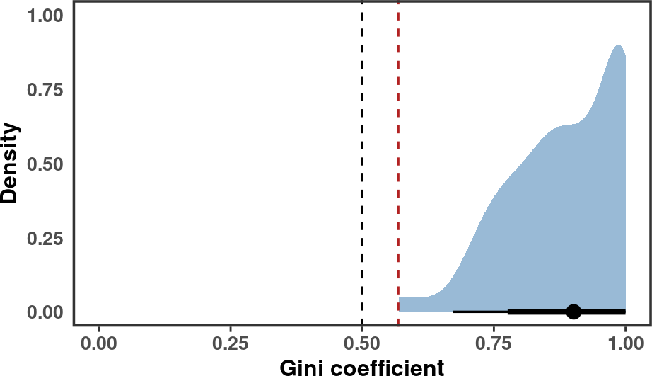

```r
fetchDensityPlot(srgnt)
```

The red vertical dashed-line marks the lower-leg of the `gini.sigma` of the distribution (mean-3*SD). The black vertical dashed-line marks the `gini.min`.

To explore the expression of genes that were used in annotation, we pass the `srgnt` object to `fetchDotPlot` function with the following command:

[figure not shown]

```r
fetchDotPlot(srgnt, min.pct=0.1) +
  theme(axis.text.y=element_text(size=17),
        legend.title=element_text(size=14),
          legend.text=element_text(size=13)) +
  scale_x_discrete(limits = c("Endo", "Epit", "TNK", "B", "MPh"))
```

Instead of making a dot-plot, we can directly explore the annotation outcomes. Sargent object includes a `data.frame` which contains a summary of outcomes for given cell-types and gene markers in the following columns:

- `cell_count`: number of cells per cell-type,
- `cell_exp_count`: number of cells that express a given gene,
- `pct_exp`: fraction of cells that express a given gene,
- `mean_exp`: average expression,
- `z_score`: z-score calculated across given cell-types.

This summary is accessible with the following command:

```r
# gene expression summary for each marker
print(head(srgnt@celltype_summary, 6))
```

```
## # A tibble: 6 × 7
##   celltype gene   cell_count cell_exp_count pct_exp mean_exp z_score
##   <ord>    <ord>       <int>          <int>   <dbl>    <dbl>   <dbl>
## 1 B        ADGRL4         19              0  0        0       -0.447
## 2 B        ANPEP          19              0  0        0       -0.855
## 3 B        AQP1           19              1  0.0526   0.158   -0.482
## 4 B        CD14           19              0  0        0       -0.657
## 5 B        CD19           19              5  0.263    0.263    1.79
## 6 B        CD1C           19              1  0.0526   0.0526   1.79
```

# 4 Sub-annotation

`fetchCell` function allows us to extract cell-ids assigned to a specific cell-type, (e.g. the `TNK` cell-type):

```r
# get cells annotated as T or Natural Killer cells (TNKs)
cells <- fetchCell(srgnt, cell.types="TNK")$cell
print(cells[1:5])
```

```
## [1] "ATTCCATCACCTTCCA_TSP2_Kidney_NA_10X_1_1"
## [2] "CAACGATAGGCTCACC_TSP2_Kidney_NA_10X_1_1"
## [3] "GAGGCCTTCTTTGCTA_TSP2_Kidney_NA_10X_1_1"
## [4] "GGAACCCTCCGATCTC_TSP2_Kidney_NA_10X_1_1"
## [5] "GGGTTTAAGGATTTAG_TSP2_Kidney_NA_10X_1_1"
```

Next, we build a new recipe to distinguish T cells from Natural Killer cells, followed by construction of a nearest-neighbor graph for the `TNK` subpopulation:

```r
# list of gene markers
gene.sets.tnk <- list("T" = c("CD4", "CD3D", "CD3E", "CD3G", "IL7R", "CD8A", "CD8B", "FOXP3", "TIGIT",
                              "CD27", "NKG7", "GNLY"),
                      "NK" = c("KLRF1", "KLRC1", "KLRC2", "NCAM1", "FGFBP2", "FCGR3A", "CX3CR1",
                               "NCR1", "FCER1G", "KDELC1", "NKG7", "GNLY", "KLRD1", "CD7"))

# Nearest-neighbor graph construction
adj.mtx.tnk <- attr(CreateSeuratObject(counts=gex) %>%
                      subset(., cell=cells) %>%
                      NormalizeData(., normalization.method="LogNormalize", scale.factor=1e6, verbose=FALSE) %>%
                      FindVariableFeatures(., selection.method="vst", nfeatures=2000, verbose=FALSE) %>%
                      ScaleData(., do.scale=TRUE, do.center=TRUE, verbose=FALSE) %>%
                      RunPCA(., features=VariableFeatures(.), npcs=15, verbose=FALSE) %>%
                      FindNeighbors(., reduction="pca", dims=1:15, k.param=5, verbose=FALSE),
                    which="graphs")[["RNA_nn"]]
```

An additional functionality of `sargent` is its ability to incorporate lowly expressed signatures. By default, the signature genes are expected to be highly expressed in one particular cell-type compared to all other cell-types. However, genes that are characteristically lowly expressed in one cell-type compared to the other cell-types can also be used as signatures. For example, the lack of expression of ‘IL7R’, ‘CD3D’, and ‘CD8A’ in Natural Killer cells can be utilized as a part of their signature. This functionality helps to increase dispersion in assignment scores among cell-types with similar expression profiles. Investigators can use `gene.sets.neg` argument in `sargentAnnotation` function to introduce lowly expressed signatures:

```r
# annotate TNK subset
 srgnt_tnk <- sargentAnnotation(gex=gex,
                                cells=cells,
                                gene.sets=gene.sets.tnk,
                                gene.sets.neg = list("T" = c("KLRF1", "KLRC1"),
                                                     "NK" = c("IL7R", "CD3D", "CD8A")),
                                adjacent.mtx=adj.mtx.tnk)
 print(srgnt_tnk)
## NK  T
##  3 14
```

The expression of selected signatures can also be explored with the `fetchDotPlot` function:

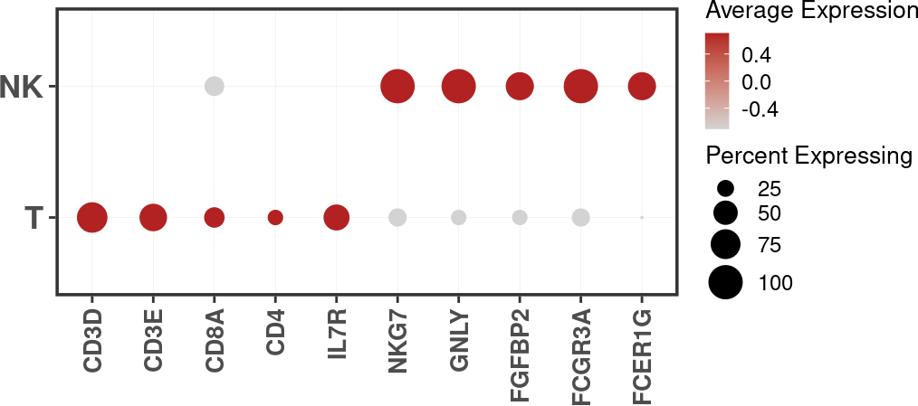

```r
genes <- c("CD3D", "CD3E", "CD8A", "CD4","IL7R",
           "NKG7", "GNLY", "FGFBP2", "FCGR3A", "FCER1G")
fetchDotPlot(srgnt_tnk, genes=genes) +
    theme(axis.text.y=element_text(size=13),
          legend.key.height=grid::unit(8, "points"),
          legend.key.width=grid::unit(10, "points"),
          legend.spacing=grid::unit(7, "points"))
```

# 5 Novel Cell-type Discovery

`sargent` can also be used to discover novel cell-types. For example, in this demo, we seek to identify regulatory cells among annotated T cells. Again, the first step is to develop a recipe of signature genes. Then, `sargent` calculates assignment scores according to the gene-set. The assignment score distribution tends to be bi-modal, where the lower mode represents cells with low expression of signature genes (`TBD`s) and the higher mode represents those with high expression of signature genes (`REG`s in this scenario). Therefore, a reasonable choice of score threshold is one that separates these two modes. Investigators can use `only.score` argument from `sargentAnnotation` to first visualize the distribution of assignment scores:

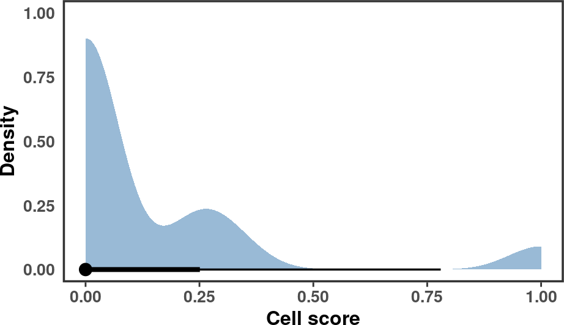

```r
# get cells annotated as T cells
cells <- fetchCell(srgnt_tnk, cell.types="T")$cell

# regulatory gene signitures
gene_sets_treg <- list("REG" = c("FOXP3", "TIGIT",  "CTLA4",
                                 "IL2RA", "TNFRSF9", "IKZF2"))

# calculate assignment scores
srgnt_scr <- sargentAnnotation(gex=gex, cells=cells,
                               gene.sets=gene_sets_treg, only.score=TRUE)

# visulaize score distribution
fetchDensityPlot(srgnt_scr)
```

```r
# annotate cells
srgnt_treg <- sargentAnnotation(gex=gex, cells=cells,
                                gene.sets=gene_sets_treg, score.threshold=0.2)

# print outcome
print(srgnt_treg)
## REG TBD
##   4  10
```

A summary of annotation outcomes is accessible with the following command:

```r
# gene expression summary for each marker
print(head(srgnt_treg@celltype_summary, 12))
```

```
## # A tibble: 12 × 7
##    celltype gene    cell_count cell_exp_count pct_exp mean_exp z_score
##    <ord>    <ord>        <int>          <int>   <dbl>    <dbl>   <dbl>
##  1 REG      CTLA4            4              4    1        2.5    0.707
##  2 REG      FOXP3            4              2    0.5      0.75   0.707
##  3 REG      IKZF2            4              2    0.5      1.25   0.707
##  4 REG      IL2RA            4              1    0.25     0.75   0.707
##  5 REG      TIGIT            4              3    0.75     0.75   0.707
##  6 REG      TNFRSF9          4              1    0.25     0.25   0.707
##  7 TBD      CTLA4           10              1    0.1      0.1   -0.707
##  8 TBD      FOXP3           10              0    0        0     -0.707
##  9 TBD      IKZF2           10              0    0        0     -0.707
## 10 TBD      IL2RA           10              0    0        0     -0.707
## 11 TBD      TIGIT           10              0    0        0     -0.707
## 12 TBD      TNFRSF9         10              0    0        0     -0.707
```

Another functionality of `sargent` that we use in this training is `fetchMergeSargents`. This function combines multiple `sargentObject`s into one `data.frame` based on the given cell ids. If a cell id appears in multiple objects, it will separate its labels by `.`. This function is useful when investigators intend to follow a hierarchical annotation workflow:

```r
print(srgnt)
```

```
##    B Endo Epit  MPh  TNK
##   19   16   25   23   17
```

```r
print(srgnt_tnk)
## NK  T
##  3 14

print(srgnt_treg)
## REG TBD
##   4  10

# merge three sargent objects to one data.frame
srgnt_all <- fetchMergeSargents(srgnt, srgnt_tnk, srgnt_treg)
print(head(srgnt_all, 10))
```

```
##                                       cell  celltype
## 1  AACAAGACACCGGTCA_TSP2_Kidney_NA_10X_1_1      Endo
## 2  AACGAAATCCTCTCTT_TSP2_Kidney_NA_10X_1_2      Endo
## 3  AACGTCAAGGCAGGGA_TSP2_Kidney_NA_10X_1_2       MPh
## 4  ACCTACCCAAAGCTAA_TSP2_Kidney_NA_10X_1_2         B
## 5  ACGTACATCTTGTGCC_TSP2_Kidney_NA_10X_1_2      Epit
## 6  ACTGTCCGTCCTGTCT_TSP2_Kidney_NA_10X_1_2 TNK.T.TBD
## 7  ACTTAGGCAATTGTGC_TSP2_Kidney_NA_10X_1_1         B
## 8  AGAAGTAGTTAGCGGA_TSP2_Kidney_NA_10X_1_1         B
## 9  AGACCCGGTGGTTTGT_TSP2_Kidney_NA_10X_1_1       MPh
## 10 AGATAGAAGGAACGAA_TSP2_Kidney_NA_10X_1_1      Epit
```

```r
print(table(srgnt_all$celltype))
```

```
##
##         B      Endo      Epit       MPh    TNK.NK TNK.T.REG TNK.T.TBD
##        19        16        25        23         3         4        10
```

# 6 FAQs

*Can gene signatures be shared across multiple cell-types?*

Yes, gene signatures can be shared across multiple cell-types. However, the elements of annotating recipe should be decisive enough (i.e., include markers unique to a specific cell-type) to guide `sargent` to accurately distinguish cell-types.

*What is the best strategy to achieve an accurate annotation?*

A prudent strategy to improve annotation accuracy is to build a hierarchy of known cell-types and perform sub-annotation in each level, until the desired granularity is achieved.

# 7 Citing Sargent

If you use Sargent in your work please cite our paper:

```r
citation("sargent")
```

[output not shown]

# Session information

```r
date()
```

```
## [1] "Wed Sep 28 20:33:24 2022"
```

# References

Consortium*, Tabula Sapiens, Robert C Jones, Jim Karkanias, Mark A Krasnow, Angela Oliveira Pisco, Stephen R Quake, Julia Salzman, et al. 2022. “The Tabula Sapiens: A Multiple-Organ, Single-Cell Transcriptomic Atlas of Humans.” *Science* 376 (6594): eabl4896.